# Project10

Kuete Tchinda Jaures

2026-01-29

```r
knitr::opts_chunk$set(echo = TRUE)
```

## R Markdown

```r
# Reproducibility
set.seed(123)

# Laden notwendigen libraries
library(readxl)
library(dplyr)
```

```r
library(ggplot2)
library(corrplot)
# Datensatz laden
data_raw <- read_excel("ENB2012_data.xlsx")

# First look
str(data_raw)
```

```
## tibble [768 × 10] (S3: tbl_df/tbl/data.frame)
##  $ X1: num [1:768] 0.98 0.98 0.98 0.98 0.9 0.9 0.9 0.9 0.86 0.86 ...
##  $ X2: num [1:768] 514 514 514 514 564 ...
##  $ X3: num [1:768] 294 294 294 294 318 ...
##  $ X4: num [1:768] 110 110 110 110 122 ...
##  $ X5: num [1:768] 7 7 7 7 7 7 7 7 7 7 ...
##  $ X6: num [1:768] 2 3 4 5 2 3 4 5 2 3 ...
##  $ X7: num [1:768] 0 0 0 0 0 0 0 0 0 0 ...
##  $ X8: num [1:768] 0 0 0 0 0 0 0 0 0 0 ...
##  $ Y1: num [1:768] 15.6 15.6 15.6 15.6 20.8 ...
##  $ Y2: num [1:768] 21.3 21.3 21.3 21.3 28.3 ...
```

```r
summary(data_raw)
```

```
##        X1               X2              X3              X4
##  Min.   :0.6200   Min.   :514.5   Min.   :245.0   Min.   :110.2
##  1st Qu.:0.6825   1st Qu.:606.4   1st Qu.:294.0   1st Qu.:140.9
##  Median :0.7500   Median :673.8   Median :318.5   Median :183.8
##  Mean   :0.7642   Mean   :671.7   Mean   :318.5   Mean   :176.6
##  3rd Qu.:0.8300   3rd Qu.:741.1   3rd Qu.:343.0   3rd Qu.:220.5
##  Max.   :0.9800   Max.   :808.5   Max.   :416.5   Max.   :220.5
##        X5             X6             X7               X8              Y1
##  Min.   :3.50   Min.   :2.00   Min.   :0.0000   Min.   :0.000   Min.   : 6.01
##  1st Qu.:3.50   1st Qu.:2.75   1st Qu.:0.1000   1st Qu.:1.750   1st Qu.:12.99
##  Median :5.25   Median :3.50   Median :0.2500   Median :3.000   Median :18.95
##  Mean   :5.25   Mean   :3.50   Mean   :0.2344   Mean   :2.812   Mean   :22.31
##  3rd Qu.:7.00   3rd Qu.:4.25   3rd Qu.:0.4000   3rd Qu.:4.000   3rd Qu.:31.67
##  Max.   :7.00   Max.   :5.00   Max.   :0.4000   Max.   :5.000   Max.   :43.10
##        Y2
##  Min.   :10.90
##  1st Qu.:15.62
##  Median :22.08
##  Mean   :24.59
##  3rd Qu.:33.13
##  Max.   :48.03
```

## Including Plots

5.1.2 Variable-Namen sauber machen

```r
# Rename variables for clarity
data <- data_raw %>%
  rename(
    Relative_Compactness = X1,
    Surface_Area        = X2,
    Wall_Area           = X3,
    Roof_Area           = X4,
    Overall_Height      = X5,
    Orientation         = X6,
    Glazing_Area        = X7,
    Glazing_Distribution= X8,
    Heating_Load        = Y1,
    Cooling_Load        = Y2
  )
names(data)
```

```
##  [1] "Relative_Compactness" "Surface_Area"         "Wall_Area"
##  [4] "Roof_Area"            "Overall_Height"       "Orientation"
##  [7] "Glazing_Area"         "Glazing_Distribution" "Heating_Load"
## [10] "Cooling_Load"
```

```r
# Missing values
colSums(is.na(data))
```

```
## Relative_Compactness         Surface_Area            Wall_Area
##                    0                    0                    0
##            Roof_Area       Overall_Height          Orientation
##                    0                    0                    0
##         Glazing_Area Glazing_Distribution         Heating_Load
##                    0                    0                    0
##         Cooling_Load
##                    0
```

5.1.3 Datentypen prüfen (sehr wichtig für spätere Tests!)

```r
# Check structure again
str(data)
```

```
## tibble [768 × 10] (S3: tbl_df/tbl/data.frame)
##  $ Relative_Compactness: num [1:768] 0.98 0.98 0.98 0.98 0.9 0.9 0.9 0.9 0.86 0.86 ...
##  $ Surface_Area        : num [1:768] 514 514 514 514 564 ...
##  $ Wall_Area           : num [1:768] 294 294 294 294 318 ...
##  $ Roof_Area           : num [1:768] 110 110 110 110 122 ...
##  $ Overall_Height      : num [1:768] 7 7 7 7 7 7 7 7 7 7 ...
##  $ Orientation         : num [1:768] 2 3 4 5 2 3 4 5 2 3 ...
##  $ Glazing_Area        : num [1:768] 0 0 0 0 0 0 0 0 0 0 ...
##  $ Glazing_Distribution: num [1:768] 0 0 0 0 0 0 0 0 0 0 ...
##  $ Heating_Load        : num [1:768] 15.6 15.6 15.6 15.6 20.8 ...
##  $ Cooling_Load        : num [1:768] 21.3 21.3 21.3 21.3 28.3 ...
```

```r
# Check structure of variable to change in cathegorical
unique(data$Glazing_Distribution)
```

```
## [1] 0 1 2 3 4 5
```

```r
table(data$Glazing_Distribution)
```

```
##
##   0   1   2   3   4   5
##  48 144 144 144 144 144
```

```r
unique(data$Orientation)
```

```
## [1] 2 3 4 5
```

```r
table(data$Orientation)
```

```
##
##   2   3   4   5
## 192 192 192 192
```

```r
# [1] 0 1 2 3 4 5
```

```r
# change  Glazing_Distribution in cathegorical variable
data <- data %>%
  mutate(

    Glazing_Distribution = factor(Glazing_Distribution,
                                  levels = c(0, 1, 2, 3, 4, 5),
                                  labels = c("Uniform", "North", "East", "South", "West", "Unknown")
                                  )
  )


str(data)
```

```
## tibble [768 × 10] (S3: tbl_df/tbl/data.frame)
##  $ Relative_Compactness: num [1:768] 0.98 0.98 0.98 0.98 0.9 0.9 0.9 0.9 0.86 0.86 ...
##  $ Surface_Area        : num [1:768] 514 514 514 514 564 ...
##  $ Wall_Area           : num [1:768] 294 294 294 294 318 ...
##  $ Roof_Area           : num [1:768] 110 110 110 110 122 ...
##  $ Overall_Height      : num [1:768] 7 7 7 7 7 7 7 7 7 7 ...
##  $ Orientation         : num [1:768] 2 3 4 5 2 3 4 5 2 3 ...
##  $ Glazing_Area        : num [1:768] 0 0 0 0 0 0 0 0 0 0 ...
##  $ Glazing_Distribution: Factor w/ 6 levels "Uniform","North",..: 1 1 1 1 1 1 1 1 1 1 ...
##  $ Heating_Load        : num [1:768] 15.6 15.6 15.6 15.6 20.8 ...
##  $ Cooling_Load        : num [1:768] 21.3 21.3 21.3 21.3 28.3 ...
```

```r
# change  Orientation in cathegorical variable
data <- data %>%
  mutate(
    Orientation = factor(Orientation,
                         levels = c(2, 3, 4, 5),
                         labels = c("North", "East", "South", "West")
                         )
  )
```

```r
str(data)
```

```
## tibble [768 × 10] (S3: tbl_df/tbl/data.frame)
##  $ Relative_Compactness: num [1:768] 0.98 0.98 0.98 0.98 0.9 0.9 0.9 0.9 0.86 0.86 ...
##  $ Surface_Area        : num [1:768] 514 514 514 514 564 ...
##  $ Wall_Area           : num [1:768] 294 294 294 294 318 ...
##  $ Roof_Area           : num [1:768] 110 110 110 110 122 ...
##  $ Overall_Height      : num [1:768] 7 7 7 7 7 7 7 7 7 7 ...
##  $ Orientation         : Factor w/ 4 levels "North","East",..: 1 2 3 4 1 2 3 4 1 2 ...
##  $ Glazing_Area        : num [1:768] 0 0 0 0 0 0 0 0 0 0 ...
##  $ Glazing_Distribution: Factor w/ 6 levels "Uniform","North",..: 1 1 1 1 1 1 1 1 1 1 ...
##  $ Heating_Load        : num [1:768] 15.6 15.6 15.6 15.6 20.8 ...
##  $ Cooling_Load        : num [1:768] 21.3 21.3 21.3 21.3 28.3 ...
```

```r
table(data$Orientation)
```

```
##
## North  East South  West
##   192   192   192   192
```

```r
table(data$Glazing_Distribution)
```

```
##
## Uniform   North    East   South    West Unknown
##      48     144     144     144     144     144
```

```r
# check Missing values
colSums(is.na(data))
```

```
## Relative_Compactness         Surface_Area            Wall_Area
##                    0                    0                    0
##            Roof_Area       Overall_Height          Orientation
##                    0                    0                    0
##         Glazing_Area Glazing_Distribution         Heating_Load
##                    0                    0                    0
##         Cooling_Load
##                    0
```

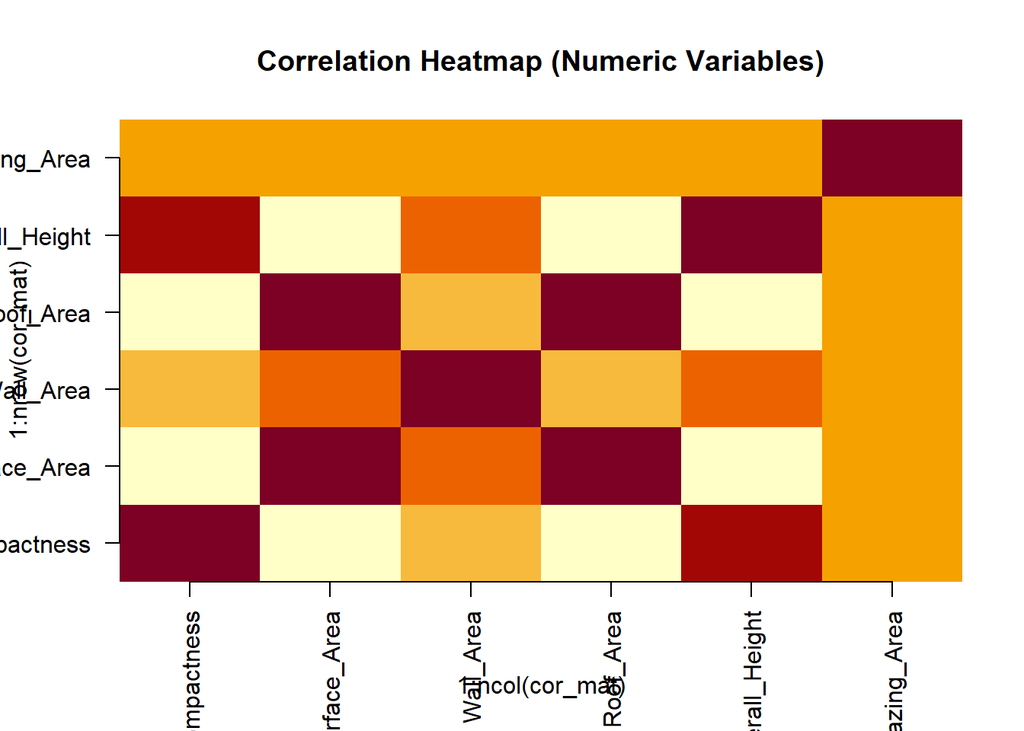

```r
# store Numerical features in variable num_vars
num_vars <- data %>%
  select(
    Relative_Compactness,
    Surface_Area,
    Wall_Area,
    Roof_Area,
    Overall_Height,
    Glazing_Area
  )

# image correlation matrix of numeric Variables
cor_mat <- cor(num_vars, use = "pairwise.complete.obs")

image(
  1:ncol(cor_mat),
  1:nrow(cor_mat),
  cor_mat,
  axes = FALSE,
  main = "Correlation Heatmap (Numeric Variables)"
)
axis(1, at = 1:ncol(cor_mat), labels = colnames(cor_mat), las = 2)
axis(2, at = 1:nrow(cor_mat), labels = rownames(cor_mat), las = 2)
```

```r
# correlation matrix
cor_mat
```

```
##                      Relative_Compactness  Surface_Area     Wall_Area
## Relative_Compactness         1.000000e+00 -9.919015e-01 -2.037817e-01
## Surface_Area                -9.919015e-01  1.000000e+00  1.955016e-01
## Wall_Area                   -2.037817e-01  1.955016e-01  1.000000e+00
## Roof_Area                   -8.688234e-01  8.807195e-01 -2.923165e-01
## Overall_Height               8.277473e-01 -8.581477e-01  2.809757e-01
## Glazing_Area                -4.482667e-20 -2.852449e-20  4.669761e-21
##                          Roof_Area Overall_Height  Glazing_Area
## Relative_Compactness -8.688234e-01      0.8277473 -4.482667e-20
## Surface_Area          8.807195e-01     -0.8581477 -2.852449e-20
## Wall_Area            -2.923165e-01      0.2809757  4.669761e-21
## Roof_Area             1.000000e+00     -0.9725122  8.438569e-20
## Overall_Height       -9.725122e-01      1.0000000  0.000000e+00
## Glazing_Area          8.438569e-20      0.0000000  1.000000e+00
```

Laut correlation matrix Roof_Area und Overall_Height korreliert stark (|coef| > 0.95), Um dieses Problem yu lösen, entscheiden wir die Variable Roof_Area zu löschen.

```r
# Remove Roof_Area from data
data <- data %>% select(-Roof_Area)
```

Exploratory Data Analysis (EDA)

```r
# Summary statistics
summary(data %>% select(Heating_Load, Cooling_Load))
```

```
##   Heating_Load    Cooling_Load
##  Min.   : 6.01   Min.   :10.90
##  1st Qu.:12.99   1st Qu.:15.62
##  Median :18.95   Median :22.08
##  Mean   :22.31   Mean   :24.59
##  3rd Qu.:31.67   3rd Qu.:33.13
##  Max.   :43.10   Max.   :48.03
```

Verteilungen der Heiz- und Kühllast

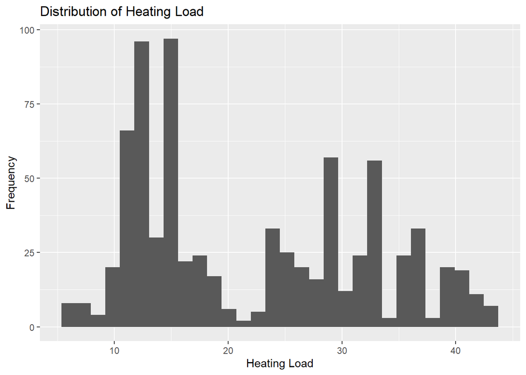

```r
# plot Distribution Heating_Load
ggplot(data, aes(x = Heating_Load)) +
  geom_histogram(bins = 30) +
  labs(title = "Distribution of Heating Load",
       x = "Heating Load",
       y = "Frequency")
```

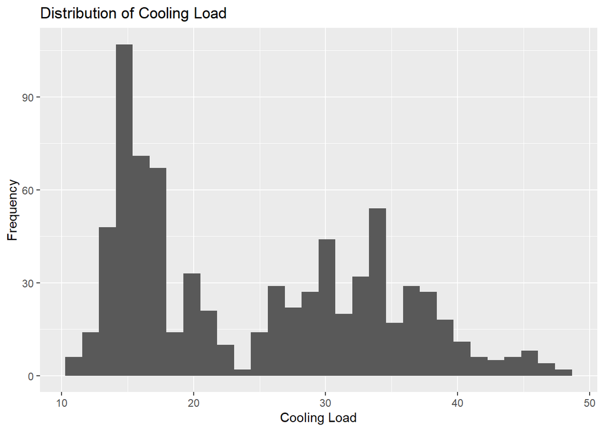

```r
# plot Distribution Cooling_Load
ggplot(data, aes(x = Cooling_Load)) +
  geom_histogram(bins = 30) +
  labs(title = "Distribution of Cooling Load",
       x = "Cooling Load",
       y = "Frequency")
```

Einfluss einzelner Design-Variablen

```r
num_design_vars <- c(
  "Relative_Compactness",
  "Surface_Area",
  "Wall_Area",
  "Overall_Height",
  "Glazing_Area"
)
```

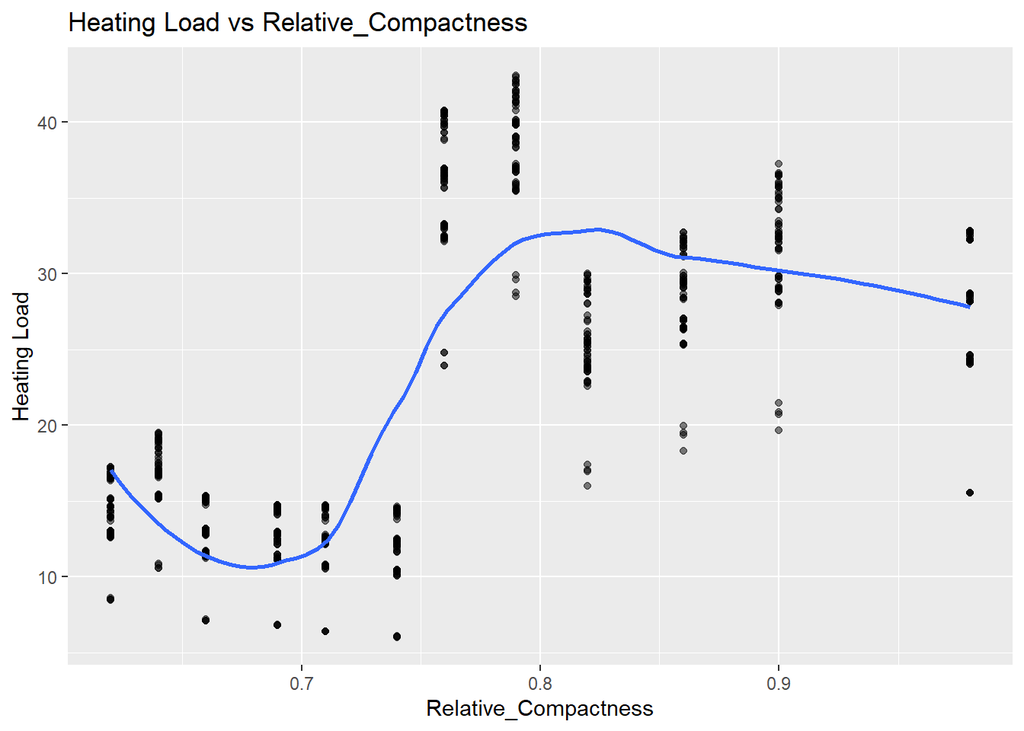

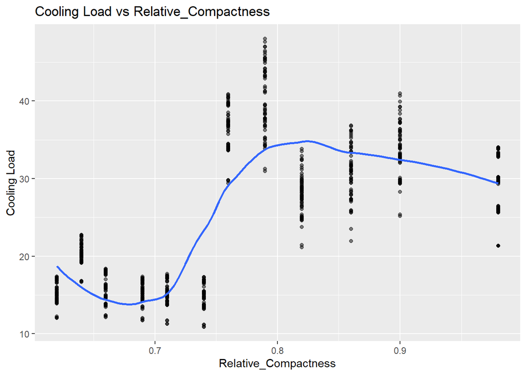

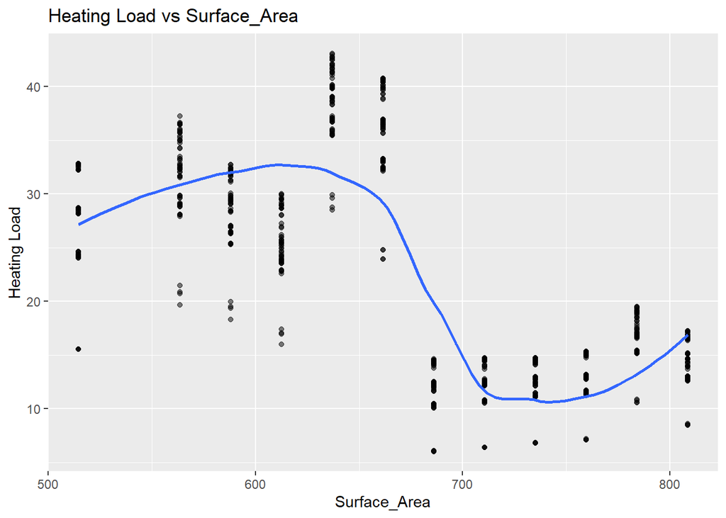

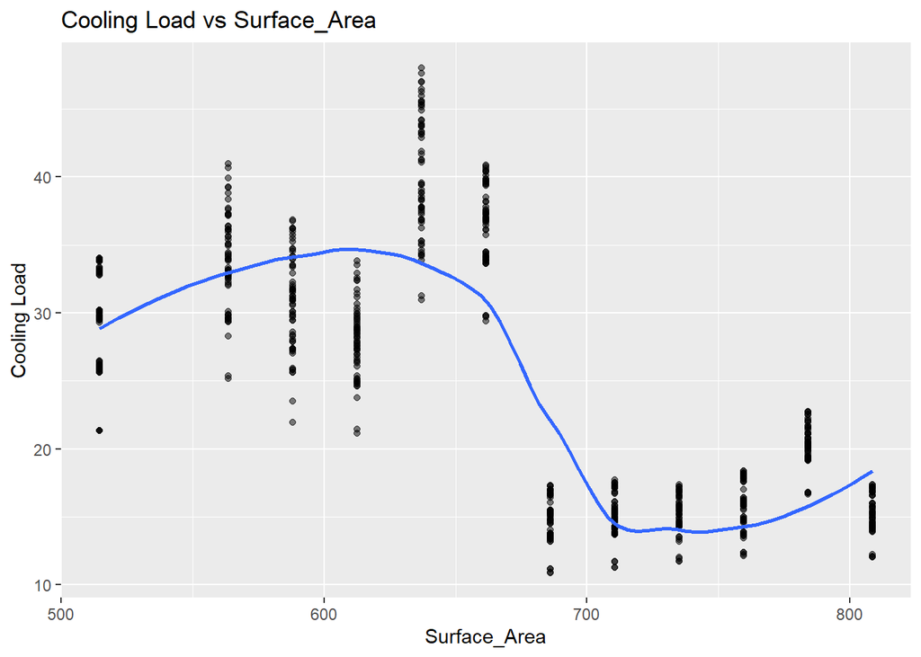

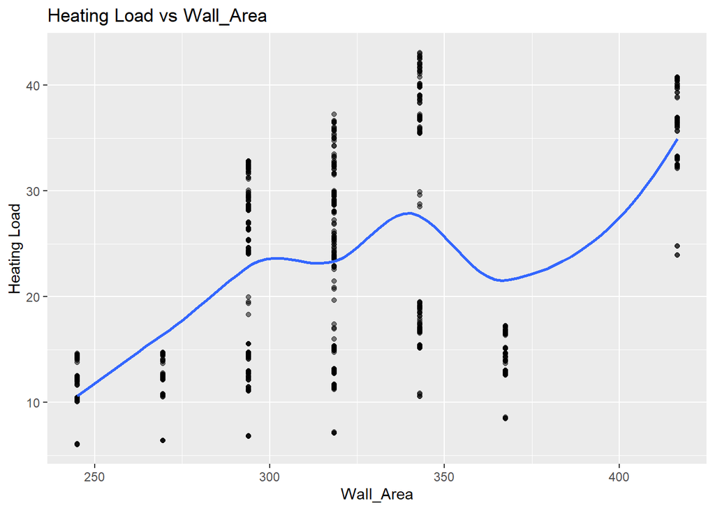

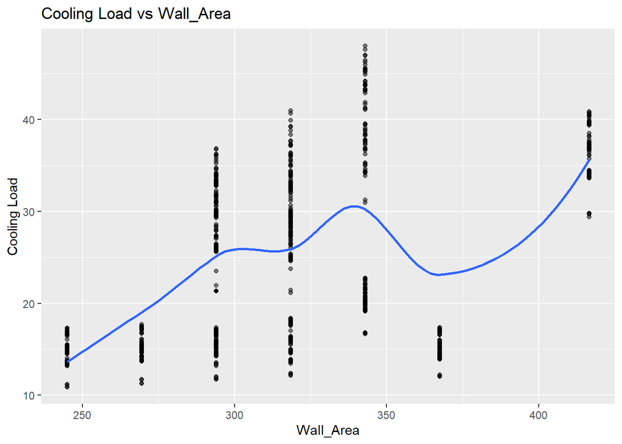

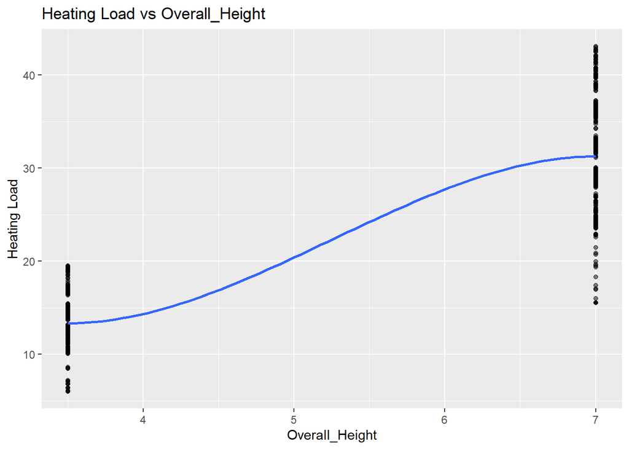

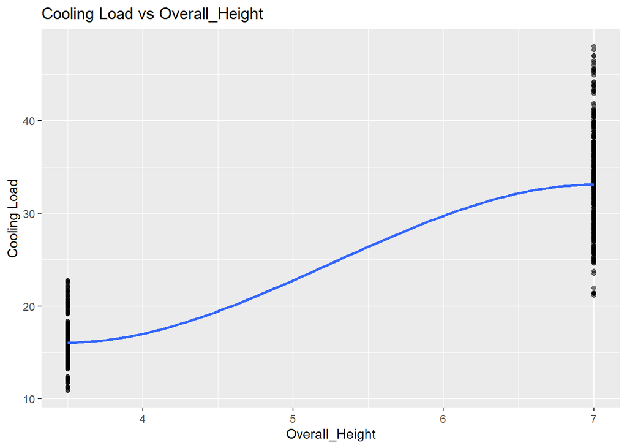

[figure not shown]

[figure not shown]

```r
# plot numerische design Vriable vs Heating_Load and Cooling Load to get influence of each design Variable on both reponse ouput

for (var in num_design_vars) {

  # Heating Load
  print(
    ggplot(data, aes_string(x = var, y = "Heating_Load")) +
      geom_point(alpha = 0.5) +
      geom_smooth(method = "loess", se = FALSE) +
      labs(
        title = paste("Heating Load vs", var),
        x = var,
        y = "Heating Load"
      )
  )

  # Cooling Load
  print(
    ggplot(data, aes_string(x = var, y = "Cooling_Load")) +
      geom_point(alpha = 0.5) +
      geom_smooth(method = "loess", se = FALSE) +
      labs(
        title = paste("Cooling Load vs", var),
        x = var,
        y = "Cooling Load"
      )
  )
}
```

Einfluss Kategoriale Variablen auf ouput variables (Heating and Cooling Load))(mit Labels)

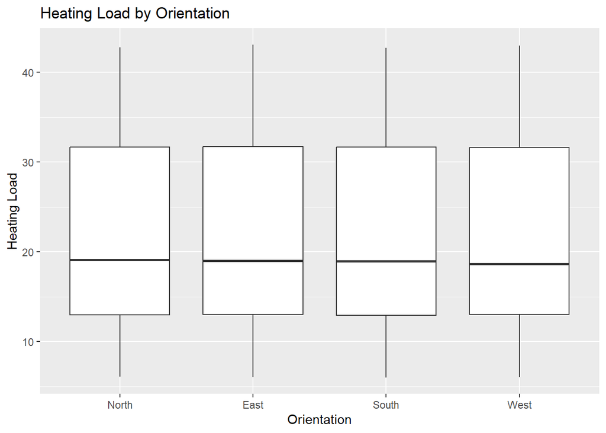

```r
# Boxplot Heating Load by Orientation to get influence of Orientation on reponse ouput Heating Load
ggplot(data, aes(x = Orientation, y = Heating_Load)) +
  geom_boxplot() +
  labs(title = "Heating Load by Orientation",
       x = "Orientation",
       y = "Heating Load")
```

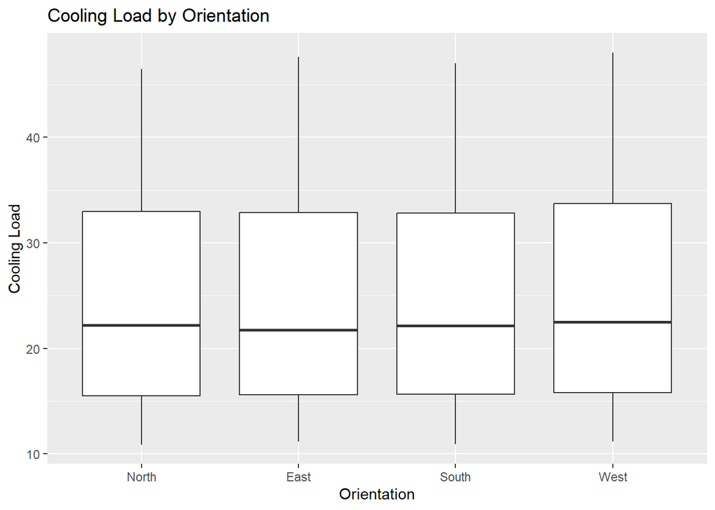

```r
# Boxplot Cooling Load by Orientation to get influence of Orientation on response ouput Cooling Load

ggplot(data, aes(x = Orientation, y = Cooling_Load)) +
  geom_boxplot() +
  labs(title = "Cooling Load by Orientation",
       x = "Orientation",
       y = "Cooling Load")
```

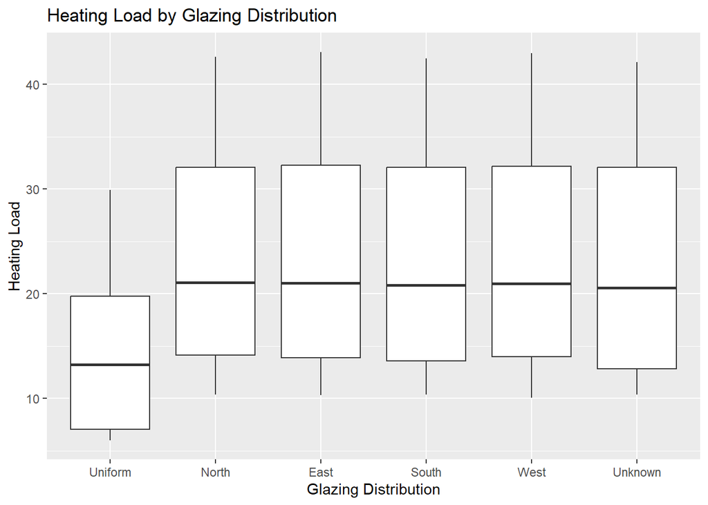

```r
# Boxplot Heating Load by Glazing Distribution to get influence of Glazing Distribution on both reponse Heating Load

ggplot(data, aes(x = Glazing_Distribution, y = Heating_Load)) +
  geom_boxplot() +
  labs(title = "Heating Load by Glazing Distribution",
       x = "Glazing Distribution",
       y = "Heating Load")
```

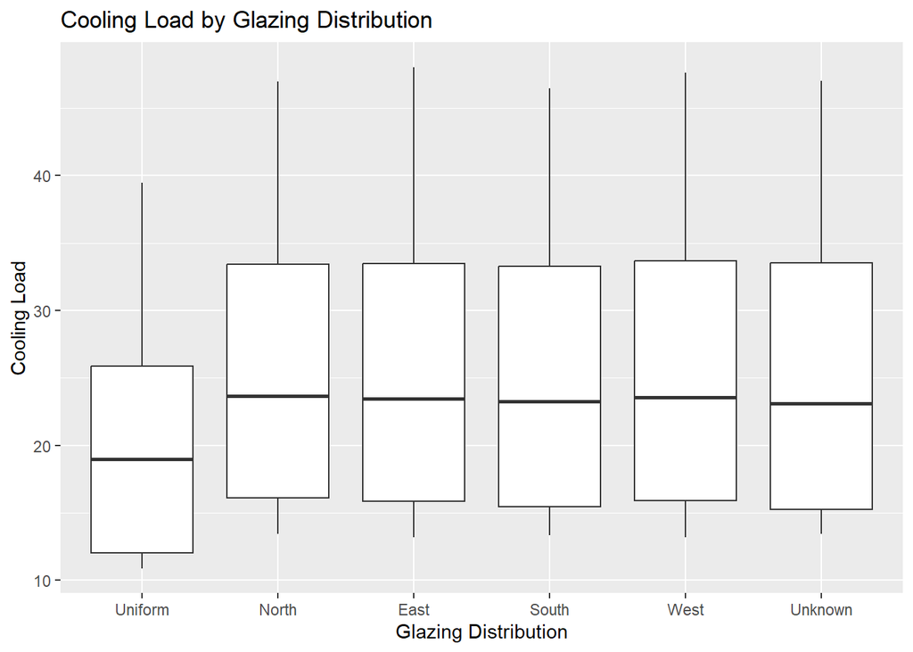

```r
# Boxplot Cooling Load by Glazing Distribution to get influence of Glazing Distribution on response ouput Cooling Load

ggplot(data, aes(x = Glazing_Distribution, y = Cooling_Load)) +
  geom_boxplot() +
  labs(title = "Cooling Load by Glazing Distribution",
       x = "Glazing Distribution",
       y = "Cooling Load")
```

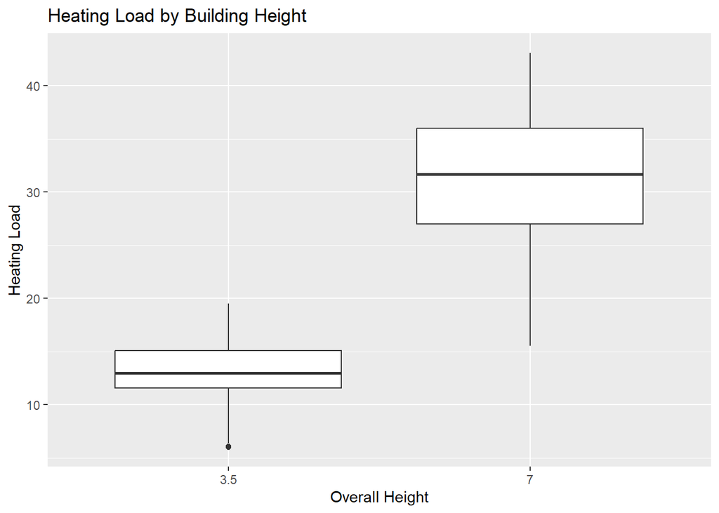

```r
# Boxplot Heating Load by Building Height to get influence of Glazing Distribution on response ouput Heating Load

ggplot(data, aes(x = factor(Overall_Height), y = Heating_Load)) +
  geom_boxplot() +
  labs(title = "Heating Load by Building Height",
       x = "Overall Height",
       y = "Heating Load")
```

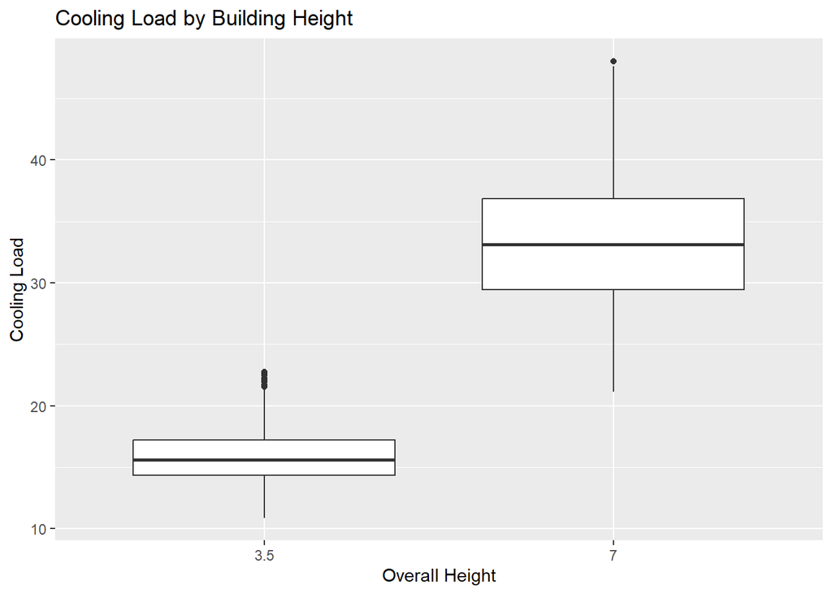

```r
# Boxplot Heating Load by Building Height to get influence of Glazing Distribution on response ouput Cooling Load

ggplot(data, aes(x = factor(Overall_Height), y = Cooling_Load)) +
  geom_boxplot() +
  labs(title = "Cooling Load by Building Height",
       x = "Overall Height",
       y = "Cooling Load")
```

Distributional Analysis and Probability

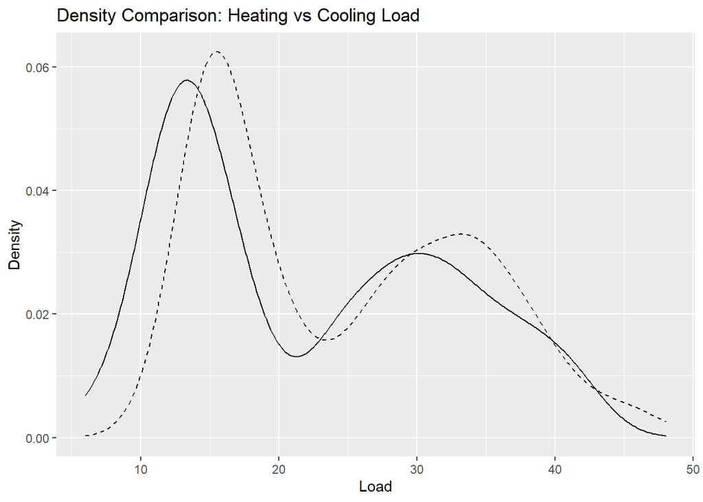

```r
# Comparison density Heating and Cooling Load in Plot
ggplot(data) +
  geom_density(aes(x = Heating_Load), linetype = "solid") +
  geom_density(aes(x = Cooling_Load), linetype = "dashed") +
  labs(title = "Density Comparison: Heating vs Cooling Load",
       x = "Load",
       y = "Density")
```

Zusammenhang zwischen Heating und Cooling Load

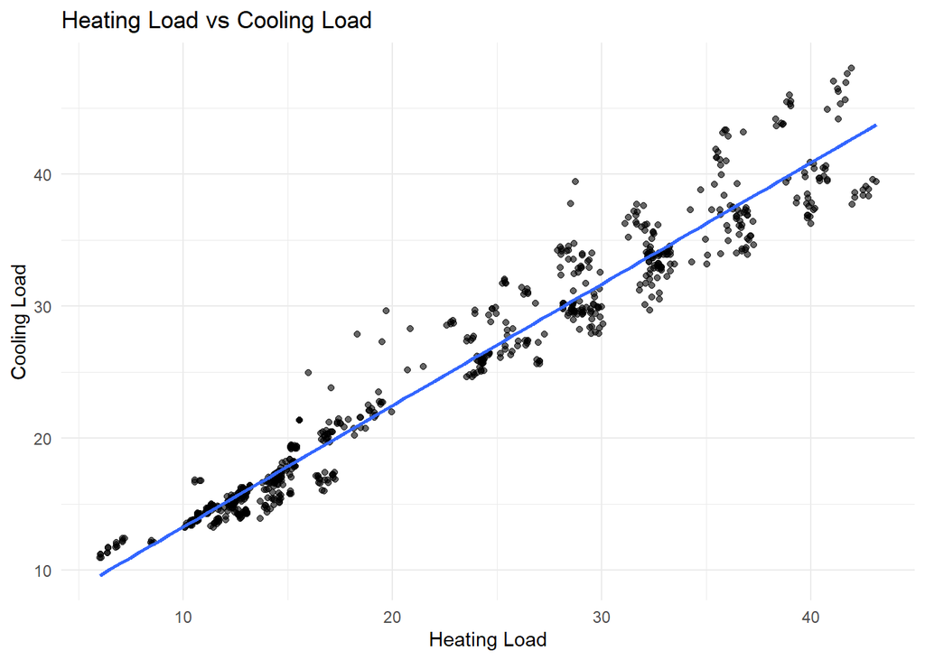

```r
# Discover the Relationship between heating load and cooling load
ggplot(data, aes(x = Heating_Load, y = Cooling_Load)) +
  geom_point(alpha = 0.6) +
  geom_smooth(method = "lm", se = FALSE) +
  theme_minimal() +
  labs(title = "Heating Load vs Cooling Load",
       x = "Heating Load",
       y = "Cooling Load")
```

Korrelation zwischen Heating und Cooling Load

```r
cor(data$Heating_Load, data$Cooling_Load, method = "spearman")
```

```
## [1] 0.9726893
```

```r
library(mclust)
```

```r
gmm_fit_heat <- Mclust(data$Heating_Load, G = 2, modelNames = "V")  # V = unequal variances

summary(gmm_fit_heat)
```

```
## ----------------------------------------------------
## Gaussian finite mixture model fitted by EM algorithm
## ----------------------------------------------------
##
## Mclust V (univariate, unequal variance) model with 2 components:
##
##  log-likelihood   n df       BIC       ICL
##       -2639.293 768  5 -5311.806 -5340.481
##
## Clustering table:
##   1   2
## 395 373
```

```r
# Extract parameters
pi_hat_heat <- gmm_fit_heat$parameters$pro     # mixing proportions (pi1, pi2)
mu_hat_heat <- gmm_fit_heat$parameters$mean    # means (mu1, mu2)
sd_hat_heat <- sqrt(gmm_fit_heat$parameters$variance$sigmasq)  # sds (sigma1, sigma2)


names(pi_hat_heat) <- names(mu_hat_heat) <- names(sd_hat_heat) <- c("Comp1", "Comp2")

cat("\nEstimated mixture parameters:\n")
```

```
##
## Estimated mixture parameters:
```

```r
print(data.frame(
  Component = names(pi_hat_heat),
  pi_heating       = pi_hat_heat,
  mu_heating        = mu_hat_heat,
  sigma_heating     = sd_hat_heat
))
```

```
##       Component pi_heating mu_heating sigma_heating
## Comp1     Comp1  0.5019939   13.34148      2.652789
## Comp2     Comp2  0.4980061   31.34470      5.863076
```

```r
# -----------------------------
# 4. Mixture CDF and Survival Functions
# -----------------------------

# Mixture CDF: P(Y <= y0)
p_mix_cdf <- function(y0, pi, mu, sigma) {
  sum(pi * pnorm(y0, mean = mu, sd = sigma))
}

# Mixture Survival: P(Y > y0)
p_mix_surv <- function(y0, pi, mu, sigma) {
  1 - p_mix_cdf(y0, pi, mu, sigma)
}

# Mixture Interval Probability: P(a < Y < b)
p_mix_interval <- function(a, b, pi, mu, sigma) {
  sum(pi * (pnorm(b, mean = mu, sd = sigma) -
              pnorm(a, mean = mu, sd = sigma)))
}


# -----------------------------
# 5. Example Probability Queries
# -----------------------------

p_y_gt_3_heat  <- p_mix_surv(30, pi_hat_heat, mu_hat_heat, sd_hat_heat)
p_y_lt_3_heat  <- p_mix_cdf(10,  pi_hat_heat, mu_hat_heat, sd_hat_heat)
p_3_5_heat     <- p_mix_interval(10, 25, pi_hat_heat, mu_hat_heat, sd_hat_heat)

cat("\nMixture-based probabilities of heating_load :\n")
```

```
##
## Mixture-based probabilities of heating_load :
```

```r
cat("P(Y > 30)     =", round(p_y_gt_3_heat,  4), "\n")
```

```
## P(Y > 30)     = 0.2942
```

```r
cat("P(Y < 10)     =", round(p_y_lt_3_heat,  4), "\n")
```

```
## P(Y < 10)     = 0.0522
```

```r
cat("P(10 < Y < 25) =", round(p_3_5_heat,     4), "\n")
```

```
## P(10 < Y < 25) = 0.5193
```

Hypothesis Testing

Hypothese 1:

H₀ (Nullhypothese): The mean Heating Load is the same for low-rise and high-rise buildings.

H₁ (Alternativhypothese): The mean Heating Load differs between low-rise and high-rise buildings.

```r
# Gruppierungsvariable erstellen
data$Height_Group <- ifelse(
  data$Overall_Height <= median(data$Overall_Height),
  "low",
  "high"
)

data$Height_Group <- factor(data$Height_Group)

table(data$Height_Group)
```

```
##
## high  low
##  384  384
```

```r
#  Zwei-Stichproben-t-Test

t.test(
  Heating_Load ~ Height_Group,
  data = data
)
```

```
##
##  Welch Two Sample t-test
##
## data:  Heating_Load by Height_Group
## t = 53.857, df = 531.21, p-value < 2.2e-16
## alternative hypothesis: true difference in means between group high and group low is not equal to 0
## 95 percent confidence interval:
##  17.28311 18.59165
## sample estimates:
## mean in group high  mean in group low
##           31.27589           13.33851
```

Hypothese 2 – Surface Area

H₀: Surface Area has no association with Heating Load.

H₁: Surface Area is associated with Heating Load.

Empfohlener Test: spearman-Rangkorrelation (robust, monotoner Zusammenhang, exakt wie in der Vorlesung)

```r
# correlation test of Surface Area and Heating Load with Spearman

cor_glazing <- cor.test(
  data$Surface_Area,
  data$Heating_Load,
  method = "spearman",
  exact = FALSE
)

cor_glazing
```

```
##
##  Spearman's rank correlation rho
##
## data:  data$Surface_Area and data$Heating_Load
## S = 122466861, p-value < 2.2e-16
## alternative hypothesis: true rho is not equal to 0
## sample estimates:
##        rho
## -0.6221347
```

Schritt 5.5 – Supervised Learning

```r
# Ouput Variable
y <- data$Heating_Load

# Select only Design Variable without response Output to build our trainning Data
X <- data %>%
  select(
    Relative_Compactness,
    Surface_Area,
    Wall_Area,
    Overall_Height,
    Orientation,
    Glazing_Area,
    Glazing_Distribution
  )
```

```r
set.seed(123)

n <- nrow(data)

# splitt our Data into train (80%) and test set (20%)
train_index <- sample(seq_len(n), size = 0.8 * n)

X_train <- X[train_index, ]
X_test  <- X[-train_index, ]

y_train <- y[train_index]
y_test  <- y[-train_index]
```

```r
# Error Measurement function
rmse <- function(y, yhat) sqrt(mean((y - yhat)^2))
mae  <- function(y, yhat) mean(abs(y - yhat))
```

```r
# Modell fitten

lm_model <- lm(
  y_train ~.,
  data = X_train
)

summary(lm_model)
```

```
##
## Call:
## lm(formula = y_train ~ ., data = X_train)
##
## Residuals:
##     Min      1Q  Median      3Q     Max
## -7.1171 -1.4095 -0.2189  1.3681  7.4223
##
## Coefficients:
##                               Estimate Std. Error t value Pr(>|t|)
## (Intercept)                  80.631921  20.194357   3.993 7.34e-05 ***
## Relative_Compactness        -65.742881  10.928873  -6.016 3.12e-09 ***
## Surface_Area                 -0.085528   0.018114  -4.722 2.91e-06 ***
## Wall_Area                     0.057821   0.007096   8.149 2.14e-15 ***
## Overall_Height                4.341400   0.361232  12.018  < 2e-16 ***
## OrientationEast              -0.111790   0.319268  -0.350    0.726
## OrientationSouth             -0.095406   0.316286  -0.302    0.763
## OrientationWest              -0.297246   0.321423  -0.925    0.355
## Glazing_Area                 15.623035   0.949537  16.453  < 2e-16 ***
## Glazing_DistributionNorth     5.278651   0.582654   9.060  < 2e-16 ***
## Glazing_DistributionEast      5.104106   0.580976   8.785  < 2e-16 ***
## Glazing_DistributionSouth     4.768639   0.579371   8.231 1.16e-15 ***
## Glazing_DistributionWest      4.886449   0.573317   8.523  < 2e-16 ***
## Glazing_DistributionUnknown   4.917054   0.579249   8.489  < 2e-16 ***
## ---
## Signif. codes:  0 '***' 0.001 '**' 0.01 '*' 0.05 '.' 0.1 ' ' 1
##
## Residual standard error: 2.799 on 600 degrees of freedom
## Multiple R-squared:  0.926,  Adjusted R-squared:  0.9244
## F-statistic: 577.7 on 13 and 600 DF,  p-value: < 2.2e-16
```

```r
# Prediction on Testdata

y_pred_lm <- predict(lm_model, newdata = X_test)
```

```r
# compute the error measurement of lm model
rmse_lm <- rmse(y_test, y_pred_lm)
mae_lm  <- mae(y_test, y_pred_lm)

mae_lm
```

```
## [1] 2.086859
```

```r
rmse_lm
```

```
## [1] 2.874481
```

Modell 2 – Ridge Regression (Regularisierung)

```r
library(glmnet)
# Design-Matrix (Dummy-Codierung)
X_train_mat <- model.matrix(~ ., data = X_train)[, -1]
X_test_mat  <- model.matrix(~ ., data = X_test)[, -1]
```

Cross-Validation für Lambda

```r
set.seed(123)

cv_ridge <- cv.glmnet(
  X_train_mat,
  y_train,
  alpha = 0   # Ridge
)

best_lambda_ridge <- cv_ridge$lambda.min
best_lambda_ridge
```

```
## [1] 0.9092934
```

Modell fitten & vorhersagen

```r
ridge_model <- glmnet(
  X_train_mat,
  y_train,
  alpha = 0,
  lambda = best_lambda_ridge
)

y_pred_ridge <- predict(
  ridge_model,
  s = best_lambda_ridge,
  newx = X_test_mat
)
```

Modellgüte

```r
# compute the error measurement of ridge model

rmse_ridge <- rmse(y_test, y_pred_ridge)
mae_ridge  <- mae(y_test, y_pred_ridge)

mae_ridge
```

```
## [1] 2.069102
```

```r
rmse_ridge
```

```
## [1] 2.986137
```

Lasso Regression

```r
cv_lasso <- cv.glmnet(
  X_train_mat,
  y_train,
  alpha = 1
)

best_lambda_lasso <- cv_lasso$lambda.min

lasso_model <- glmnet(
  X_train_mat,
  y_train,
  alpha = 1,
  lambda = best_lambda_lasso
)

y_pred_lasso <- predict(
  lasso_model,
  s = best_lambda_lasso,
  newx = X_test_mat
)

# compute the error measurement of lasso regression
rmse_lasso <- rmse(y_test, y_pred_lasso)
mae_lasso  <- mae(y_test, y_pred_lasso)

mae_lasso
```

```
## [1] 2.085093
```

```r
rmse_lasso
```

```
## [1] 2.869757
```

```r
library(randomForest)
set.seed(123)

rf_model <- randomForest(
  x = X_train,
  y = y_train,
  ntree = 500,
  mtry = floor(sqrt(ncol(X_train))),
  importance = TRUE
)

rf_model
```

```
##
## Call:
##  randomForest(x = X_train, y = y_train, ntree = 500, mtry = floor(sqrt(ncol(X_train))),      importance = TRUE)
##                Type of random forest: regression
##                      Number of trees: 500
## No. of variables tried at each split: 2
##
##           Mean of squared residuals: 0.9577799
##                     % Var explained: 99.07
```

```r
y_pred_rf <- predict(rf_model, newdata = X_test)
```

```r
# compute the error measurement of RandomForest Modell
rmse_rf <- rmse(y_test, y_pred_rf)
mae_rf  <- mae(y_test, y_pred_rf)


mae_rf
```

```
## [1] 0.7826955
```

```r
rmse_rf
```

```
## [1] 1.03024
```

```r
# Modell comparison

results <- data.frame(
  Model = c(
    "Linear Regression",
    "Ridge Regression",
    "Lasso Regression",
    "Random Forest"
  ),
  RMSE = c(
    rmse_lm,
    rmse_ridge,
    rmse_lasso,
    rmse_rf
  ),
  MAE = c(
    mae_lm,
    mae_ridge,
    mae_lasso,
    mae_rf
  )
)

results
```

```
##               Model     RMSE       MAE
## 1 Linear Regression 2.874481 2.0868595
## 2  Ridge Regression 2.986137 2.0691022
## 3  Lasso Regression 2.869757 2.0850926
## 4     Random Forest 1.030240 0.7826955
```

The best model is Random Forest because it has the smallest RMSE and MAE.

Unsupervised Learning:

Variablenauswahl für Clustering

```r
# Choose Variable numerische Variable for Unsupervised Learning

cluster_data <- data %>%
  select(
    Relative_Compactness,
    Surface_Area,
    Wall_Area,
    Overall_Height,
    Glazing_Area,
  )
```

Skalierung (zwingend für Clustering!)

```r
# scale of numerische Variable to make it comparable without mistake
cluster_scaled <- scale(cluster_data)
dist_mat <- dist(cluster_scaled, method = "euclidean")
```

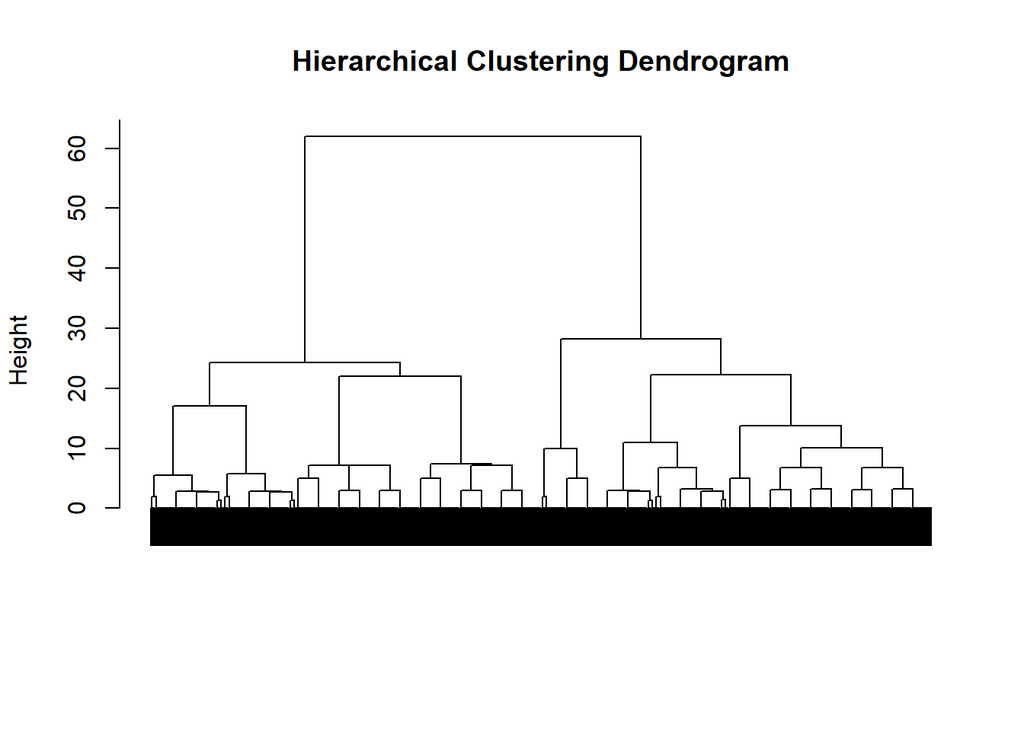

```r
# Build and Plot Dendograme to have a first Idea of number of Cluster

hc <- hclust(dist_mat, method = "ward.D2")

plot(
  hc,
  labels = FALSE,
  main = "Hierarchical Clustering Dendrogram",
  xlab = "",
  sub = ""
)
```

```r
cluster_hc <- cutree(hc, k = 2)
table(cluster_hc)
```

```
## cluster_hc
##   1   2
## 384 384
```

K-Means Clustering: Wahl der Clusteranzahl (Elbow Method)

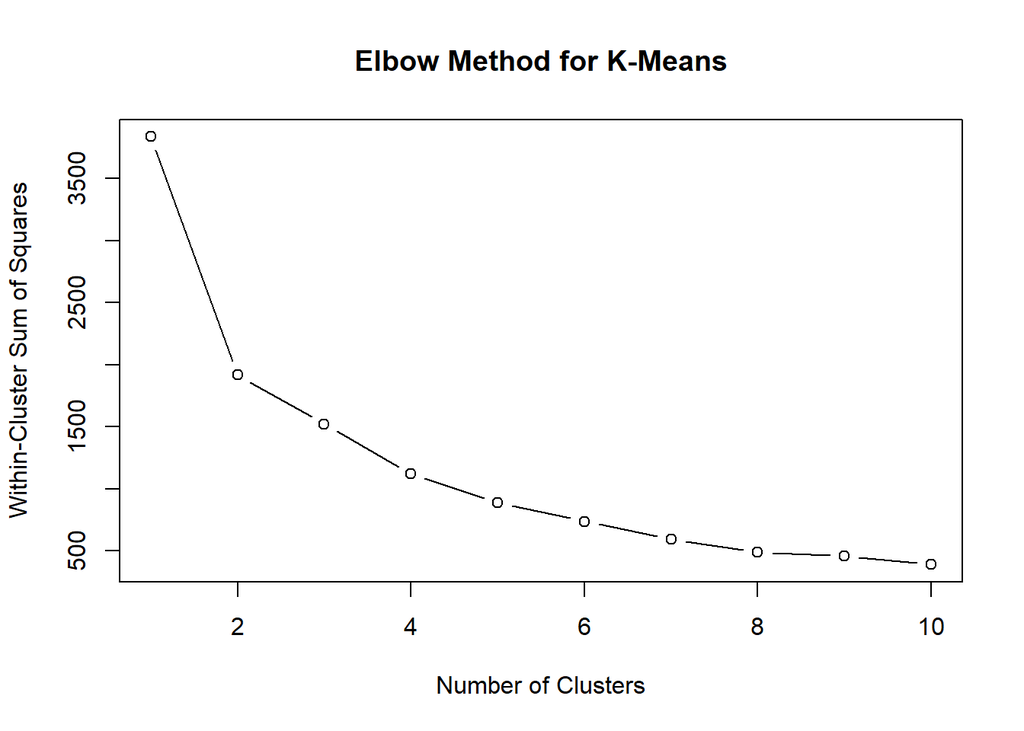

```r
set.seed(123)

# choose of  K Value of  K-Means with Elbow Method

wss <- sapply(1:10, function(k) {
  kmeans(cluster_scaled, centers = k, nstart = 25)$tot.withinss
})

plot(
  1:10, wss, type = "b",
  xlab = "Number of Clusters",
  ylab = "Within-Cluster Sum of Squares",
  main = "Elbow Method for K-Means"
)
```

K-Means mit k = 2

```r
set.seed(123)

# Build a K-Means Algorithm with K = 2
km <- kmeans(
  cluster_scaled,
  centers = 2,
  nstart = 25
)

table(km$cluster)
```

```
##
##   1   2
## 384 384
```

Cluster-Zugehörigkeit zum Datensatz hinzufügen

```r
data_clustered <- data %>%
  mutate(
    Cluster_HC = factor(cluster_hc),
    Cluster_KMeans = factor(km$cluster)
  )
```

```r
data_clustered
```

```
## # A tibble: 768 × 12
##    Relative_Compactness Surface_Area Wall_Area Overall_Height Orientation
##                   <dbl>        <dbl>     <dbl>          <dbl> <fct>
##  1                 0.98         514.      294               7 North
##  2                 0.98         514.      294               7 East
##  3                 0.98         514.      294               7 South
##  4                 0.98         514.      294               7 West
##  5                 0.9          564.      318.              7 North
##  6                 0.9          564.      318.              7 East
##  7                 0.9          564.      318.              7 South
##  8                 0.9          564.      318.              7 West
##  9                 0.86         588       294               7 North
## 10                 0.86         588       294               7 East
## # ℹ 758 more rows
## # ℹ 7 more variables: Glazing_Area <dbl>, Glazing_Distribution <fct>,
## #   Heating_Load <dbl>, Cooling_Load <dbl>, Height_Group <fct>,
## #   Cluster_HC <fct>, Cluster_KMeans <fct>
```

```r
table(data_clustered$Cluster_HC, data_clustered$Cluster_KMeans)
```

```
##
##       1   2
##   1   0 384
##   2 384   0
```

Cluster-Profil (numerisch)

```r
# Add Cluster-Profil to each Observation

aggregate(
  data_clustered %>%
    select(
      Relative_Compactness,
      Surface_Area,
      Wall_Area,
      Overall_Height,
      Glazing_Area
    ),
  by = list(Cluster = data_clustered$Cluster_KMeans),
  FUN = mean
)
```

```
##   Cluster Relative_Compactness Surface_Area Wall_Area Overall_Height
## 1       1            0.6766667     747.2500    306.25            3.5
## 2       2            0.8516667     596.1667    330.75            7.0
##   Glazing_Area
## 1     0.234375
## 2     0.234375
```

PCA durchführen (nur numerische Variablen!)

```r
# find the Principal Components of Data to reduce the data size
pca <- prcomp(cluster_scaled, center = TRUE, scale. = FALSE)
summary(pca)$importance[ , 1:5]
```

```
##                             PC1      PC2     PC3       PC4       PC5
## Standard deviation     1.670556 1.075409 1.00000 0.2228409 0.0555219
## Proportion of Variance 0.558150 0.231300 0.20000 0.0099300 0.0006200
## Cumulative Proportion  0.558150 0.789450 0.98945 0.9993800 1.0000000
```

```r
# find the Principal Components

pca
```

```
## Standard deviations (1, .., p=5):
## [1] 1.6705555 1.0754085 1.0000000 0.2228409 0.0555219
##
## Rotation (n x k) = (5 x 5):
##                                PC1           PC2           PC3           PC4
## Relative_Compactness -5.873694e-01  1.304008e-01  0.000000e+00 -5.777948e-01
## Surface_Area          5.932278e-01 -1.147286e-01 -5.926261e-16  1.225479e-01
## Wall_Area             4.552135e-02 -9.241242e-01 -1.263378e-15 -3.622847e-01
## Overall_Height       -5.486399e-01 -3.403343e-01 -9.533793e-16  7.210305e-01
## Glazing_Area         -1.139889e-16 -1.559977e-15  1.000000e+00  3.023379e-16
##                                PC5
## Relative_Compactness -5.514943e-01
## Surface_Area         -7.873374e-01
## Wall_Area             1.125702e-01
## Overall_Height       -2.515587e-01
## Glazing_Area         -5.642088e-16
```

PCA-Ergebnisse mit Clustern kombinieren

```r
pca_df <- data.frame(
  PC1 = pca$x[, 1],
  PC2 = pca$x[, 2],
  Cluster = factor(cluster_hc),
  Heating_Load = data$Heating_Load
)
str(pca_df)
```

```
## 'data.frame':    768 obs. of  4 variables:
##  $ PC1         : num  -2.83 -2.83 -2.83 -2.83 -2.03 ...
##  $ PC2         : num  0.6497 0.6497 0.6497 0.6497 -0.0317 ...
##  $ Cluster     : Factor w/ 2 levels "1","2": 1 1 1 1 1 1 1 1 1 1 ...
##  $ Heating_Load: num  15.6 15.6 15.6 15.6 20.8 ...
```

Scatterplot im PCA-Raum

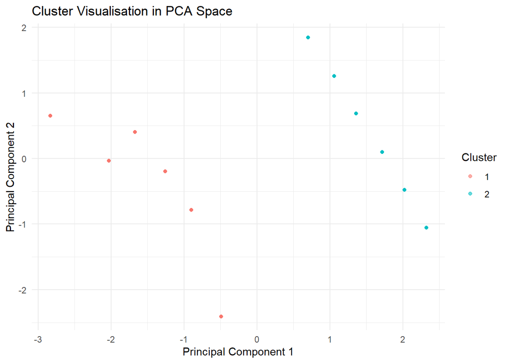

```r
# Visualisation of Cluster in PCA Space

ggplot(pca_df,
       aes(x = PC1, y = PC2, color = Cluster)) +
  geom_point(alpha = 0.6) +
  labs(
    title = "Cluster Visualisation in PCA Space",
    x = "Principal Component 1",
    y = "Principal Component 2",
    color = "Cluster"
  ) +
  theme_minimal()
```